# Importing my Libraries

```python
from bs4 import BeautifulSoup
import requests
import pandas as pd
import numpy as np
import matplotlib.pyplot as plt
import seaborn as sns
```

# Web Scrape Time

The table of interest comes from the comparison of races and their skills in one of my favorite games, The Elder Scrolls V: Skyrim.

```python
url = 'https://elderscrolls.fandom.com/wiki/Races_(Skyrim)'

page = requests.get(url)

soup = BeautifulSoup(page.text, 'html')
```

```python
print(soup)
```

[output not shown]

[output cut: 3486 more lines]

```python
print(soup.prettify())
```

[output not shown]

[output cut: 6489 more lines]

[output not shown]

Make sure to add the style part because without it, the table retrieved will be the one that talks about the different races and their unique powers/effects

```python
soup.find('table', class_ = 'wikitable', style = "text-align:center; width:100%;")
```

```
<table class="wikitable" style="text-align:center; width:100%;">
<tbody><tr>
<th>Races →<br/>Skills ↓
</th>
<th>Altmer
</th>
<th>Argonian
</th>
<th>Bosmer
</th>
<th>Breton
</th>
<th>Dunmer
</th>
<th>Imperial
</th>
<th>Khajiit
</th>
<th>Nord
</th>
<th>Orsimer
</th>
<th>Redguard
</th></tr>
<tr>
<th><a href="/wiki/Smithing_(Skyrim)" title="Smithing (Skyrim)">Smithing</a>
</th>
<td><b>15</b>
</td>
<td><b>15</b>
</td>
<td><b>15</b>
</td>
<td><b>15</b>
</td>
<td><b>15</b>
</td>
<td><b>15</b>
</td>
<td><b>15</b>
```

[output cut: 383 more lines]

```
</td>
<td><b>15</b>
</td>
<td><b>15</b>
</td>
<td style="background-color: #3F5D7D"><b>20</b>
</td>
<td><b>15</b>
</td>
<td><b>15</b>
</td>
<td style="background-color: #3F5D7D"><b>20</b>
</td>
<td><b>15</b>
</td></tr></tbody></table>
```

```python
table = soup.find_all('table')[1]
```

Here I want to get the column headers (or their titles)

```python
race_titles = table.find_all('th')
```

```python
race_titles
```

```
[<th>Races →<br/>Skills ↓
 </th>,
 <th>Altmer
 </th>,
 <th>Argonian
 </th>,
 <th>Bosmer
 </th>,
 <th>Breton
 </th>,
 <th>Dunmer
 </th>,
 <th>Imperial
 </th>,
 <th>Khajiit
 </th>,
 <th>Nord
 </th>,
 <th>Orsimer
 </th>,
 <th>Redguard
 </th>,
 <th><a href="/wiki/Smithing_(Skyrim)" title="Smithing (Skyrim)">Smithing</a>
 </th>,
 <th><a href="/wiki/Heavy_Armor_(Skyrim)" title="Heavy Armor (Skyrim)">Heavy Armor</a>
 </th>,
 <th><a href="/wiki/Block_(Skyrim)" title="Block (Skyrim)">Block</a>
 </th>,
 <th><a href="/wiki/Two-Handed_(Skyrim)" title="Two-Handed (Skyrim)">Two-Handed</a>
 </th>,
 <th><a href="/wiki/One-Handed_(Skyrim)" title="One-Handed (Skyrim)">One-Handed</a>
 </th>,
 <th><a href="/wiki/Archery_(Skyrim)" title="Archery (Skyrim)">Archery</a>
 </th>,
 <th><a href="/wiki/Light_Armor_(Skyrim)" title="Light Armor (Skyrim)">Light Armor</a>
 </th>,
 <th><a href="/wiki/Sneak_(Skyrim)" title="Sneak (Skyrim)">Sneak</a>
 </th>,
 <th><a href="/wiki/Lockpicking_(Skyrim)" title="Lockpicking (Skyrim)">Lockpicking</a>
 </th>,
 <th><a href="/wiki/Pickpocket" title="Pickpocket">Pickpocket</a>
 </th>,
 <th><a href="/wiki/Speech" title="Speech">Speech</a>
 </th>,
 <th><a href="/wiki/Alchemy_(Skyrim)" title="Alchemy (Skyrim)">Alchemy</a>
 </th>,
 <th><a href="/wiki/Illusion_(Skyrim)" title="Illusion (Skyrim)">Illusion</a>
 </th>,
 <th><a href="/wiki/Conjuration_(Skyrim)" title="Conjuration (Skyrim)">Conjuration</a>
 </th>,
 <th><a href="/wiki/Destruction_(Skyrim)" title="Destruction (Skyrim)">Destruction</a>
 </th>,
 <th><a href="/wiki/Restoration_(Skyrim)" title="Restoration (Skyrim)">Restoration</a>
 </th>,
 <th><a href="/wiki/Alteration_(Skyrim)" title="Alteration (Skyrim)">Alteration</a>
 </th>,
 <th><a href="/wiki/Enchanting_(Skyrim)" title="Enchanting (Skyrim)">Enchanting</a>
 </th>]
```

```python
race_table_titles = [title.text.strip() for title in race_titles]

print(race_table_titles)
```

```
['Races →Skills ↓', 'Altmer', 'Argonian', 'Bosmer', 'Breton', 'Dunmer', 'Imperial', 'Khajiit', 'Nord', 'Orsimer', 'Redguard', 'Smithing', 'Heavy Armor', 'Block', 'Two-Handed', 'One-Handed', 'Archery', 'Light Armor', 'Sneak', 'Lockpicking', 'Pickpocket', 'Speech', 'Alchemy', 'Illusion', 'Conjuration'…
```

# Working with a Dataframe

I successfully retrieved the titles but I still need to make some minor tweaks because all the titles were thrown into one long horizontal header. What I want is the races to go across and the skills to down the table.

```python
df = pd.DataFrame(columns = race_table_titles)

df
```

|  | Races →Skills ↓ | Altmer | Argonian | Bosmer | Breton | Dunmer | Imperial | Khajiit | Nord | Orsimer | ... | Lockpicking | Pickpocket | Speech | Alchemy | Illusion | Conjuration | Destruction | Restoration | Alteration | Enchanting |
| --- | --- | --- | --- | --- | --- | --- | --- | --- | --- | --- | --- | --- | --- | --- | --- | --- | --- | --- | --- | --- | --- |

0 rows × 29 columns

With this code, I am specifying where to start my headers so I can keep the layout and data intact.

```python
df = pd.read_html(str(table), header=[0])[0]
df
```

|  | Races → Skills ↓ | Altmer | Argonian | Bosmer | Breton | Dunmer | Imperial | Khajiit | Nord | Orsimer | Redguard |
| --- | --- | --- | --- | --- | --- | --- | --- | --- | --- | --- | --- |
| 0 | Smithing | 15 | 15 | 15 | 15 | 15 | 15 | 15 | 20 | 20 | 20 |
| 1 | Heavy Armor | 15 | 15 | 15 | 15 | 15 | 20 | 15 | 15 | 25 | 15 |
| 2 | Block | 15 | 15 | 15 | 15 | 15 | 20 | 15 | 20 | 20 | 20 |
| 3 | Two-Handed | 15 | 15 | 15 | 15 | 15 | 15 | 15 | 25 | 20 | 15 |
| 4 | One-Handed | 15 | 15 | 15 | 15 | 15 | 20 | 20 | 20 | 20 | 25 |
| 5 | Archery | 15 | 15 | 25 | 15 | 15 | 15 | 20 | 15 | 15 | 20 |
| 6 | Light Armor | 15 | 20 | 20 | 15 | 20 | 15 | 15 | 20 | 15 | 15 |
| 7 | Sneak | 15 | 20 | 20 | 15 | 20 | 15 | 25 | 15 | 15 | 15 |
| 8 | Lockpicking | 15 | 25 | 20 | 15 | 15 | 15 | 20 | 15 | 15 | 15 |
| 9 | Pickpocket | 15 | 20 | 20 | 15 | 15 | 15 | 20 | 15 | 15 | 15 |
| 10 | Speech | 15 | 15 | 15 | 20 | 15 | 15 | 15 | 20 | 15 | 15 |
| 11 | Alchemy | 15 | 15 | 20 | 20 | 20 | 15 | 20 | 15 | 15 | 15 |
| 12 | Illusion | 25 | 15 | 15 | 20 | 20 | 15 | 15 | 15 | 15 | 15 |
| 13 | Conjuration | 20 | 15 | 15 | 25 | 15 | 15 | 15 | 15 | 15 | 15 |
| 14 | Destruction | 20 | 15 | 15 | 15 | 25 | 20 | 15 | 15 | 15 | 20 |
| 15 | Restoration | 20 | 20 | 15 | 20 | 15 | 25 | 15 | 15 | 15 | 15 |
| 16 | Alteration | 20 | 20 | 15 | 20 | 20 | 15 | 15 | 15 | 15 | 20 |
| 17 | Enchanting | 20 | 15 | 15 | 15 | 15 | 20 | 15 | 15 | 20 | 15 |

```python
 print(df.to_string(index=False))
```

```
Races → Skills ↓ Altmer Argonian Bosmer Breton Dunmer Imperial Khajiit Nord Orsimer Redguard
        Smithing     15       15     15     15     15       15      15   20      20       20
     Heavy Armor     15       15     15     15     15       20      15   15      25       15
           Block     15       15     15     15     15       20      15   20      20       20
      Two-Handed     15       15     15     15     15       15      15   25      20       15
      One-Handed     15       15     15     15     15       20      20   20      20       25
         Archery     15       15     25     15     15       15      20   15      15       20
     Light Armor     15       20     20     15     20       15      15   20      15       15
           Sneak     15       20     20     15     20       15      25   15      15       15
     Lockpicking     15       25     20     15     15       15      20   15      15       15
      Pickpocket     15       20     20     15     15       15      20   15      15       15
          Speech     15       15     15     20     15       15      15   20      15       15
         Alchemy     15       15     20     20     20       15      20   15      15       15
        Illusion     25       15     15     20     20       15      15   15      15       15
     Conjuration     20       15     15     25     15       15      15   15      15       15
     Destruction     20       15     15     15     25       20      15   15      15       20
     Restoration     20       20     15     20     15       25      15   15      15       15
      Alteration     20       20     15     20     20       15      15   15      15       20
      Enchanting     20       15     15     15     15       20      15   15      20       15
```

I am renaming my column because the arrows, while helpful, just seem a little wonky.

```python
df = df.rename(columns={'Races → Skills ↓': 'Skills'})
df
```

|  | Skills | Altmer | Argonian | Bosmer | Breton | Dunmer | Imperial | Khajiit | Nord | Orsimer | Redguard |
| --- | --- | --- | --- | --- | --- | --- | --- | --- | --- | --- | --- |
| 0 | Smithing | 15 | 15 | 15 | 15 | 15 | 15 | 15 | 20 | 20 | 20 |
| 1 | Heavy Armor | 15 | 15 | 15 | 15 | 15 | 20 | 15 | 15 | 25 | 15 |
| 2 | Block | 15 | 15 | 15 | 15 | 15 | 20 | 15 | 20 | 20 | 20 |
| 3 | Two-Handed | 15 | 15 | 15 | 15 | 15 | 15 | 15 | 25 | 20 | 15 |
| 4 | One-Handed | 15 | 15 | 15 | 15 | 15 | 20 | 20 | 20 | 20 | 25 |
| 5 | Archery | 15 | 15 | 25 | 15 | 15 | 15 | 20 | 15 | 15 | 20 |
| 6 | Light Armor | 15 | 20 | 20 | 15 | 20 | 15 | 15 | 20 | 15 | 15 |
| 7 | Sneak | 15 | 20 | 20 | 15 | 20 | 15 | 25 | 15 | 15 | 15 |
| 8 | Lockpicking | 15 | 25 | 20 | 15 | 15 | 15 | 20 | 15 | 15 | 15 |
| 9 | Pickpocket | 15 | 20 | 20 | 15 | 15 | 15 | 20 | 15 | 15 | 15 |
| 10 | Speech | 15 | 15 | 15 | 20 | 15 | 15 | 15 | 20 | 15 | 15 |
| 11 | Alchemy | 15 | 15 | 20 | 20 | 20 | 15 | 20 | 15 | 15 | 15 |
| 12 | Illusion | 25 | 15 | 15 | 20 | 20 | 15 | 15 | 15 | 15 | 15 |
| 13 | Conjuration | 20 | 15 | 15 | 25 | 15 | 15 | 15 | 15 | 15 | 15 |
| 14 | Destruction | 20 | 15 | 15 | 15 | 25 | 20 | 15 | 15 | 15 | 20 |
| 15 | Restoration | 20 | 20 | 15 | 20 | 15 | 25 | 15 | 15 | 15 | 15 |
| 16 | Alteration | 20 | 20 | 15 | 20 | 20 | 15 | 15 | 15 | 15 | 20 |
| 17 | Enchanting | 20 | 15 | 15 | 15 | 15 | 20 | 15 | 15 | 20 | 15 |

# Visualization Time

I felt that a bar plot would work well for this type of data.

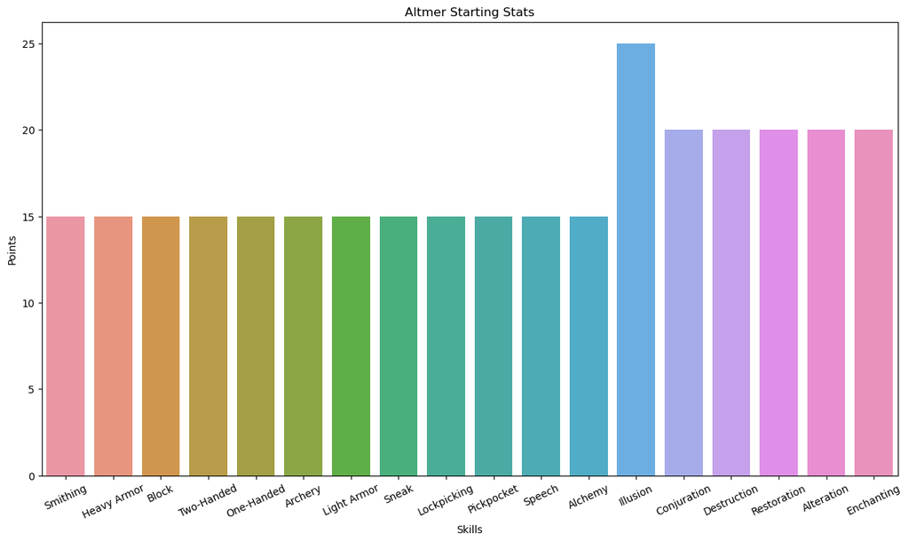

```python
plt.figure(figsize=(15, 8))
sns.barplot(data=df,
            x="Skills",
            y="Altmer")
plt.title('Altmer Starting Stats')
plt.xlabel('Skills')
# Rotate x-axis labels
plt.xticks(rotation=25)
plt.ylabel('Points')
plt.show()
```

I successfully created a visualization for the Altmer race, but it would be a pain to copy and paste this code several times. I can just use a for loop to make my life easier!

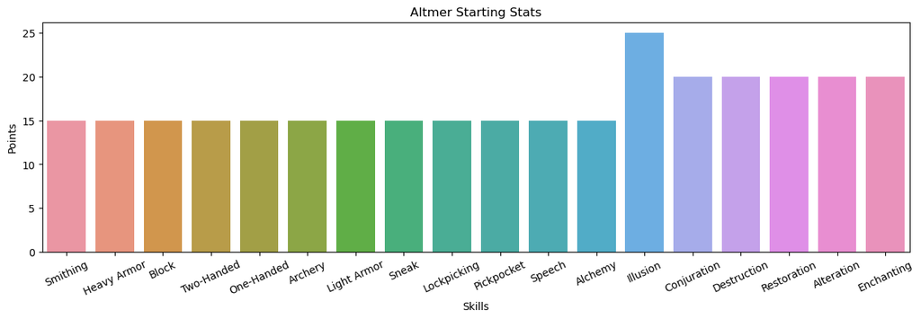

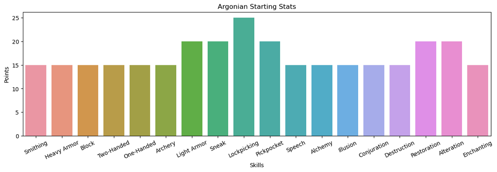

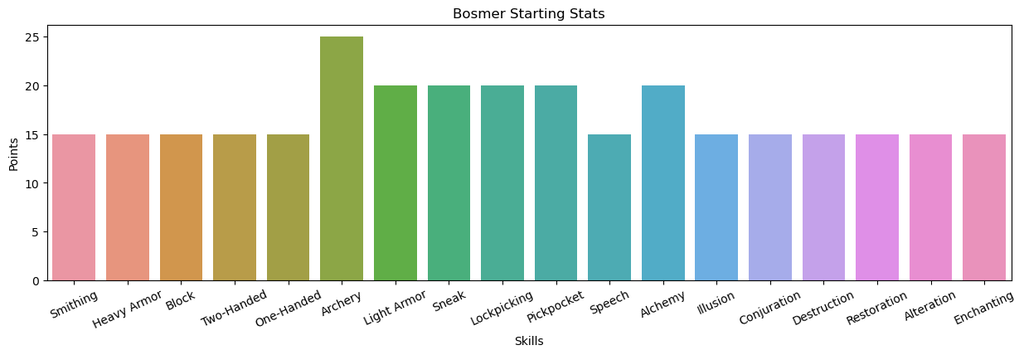

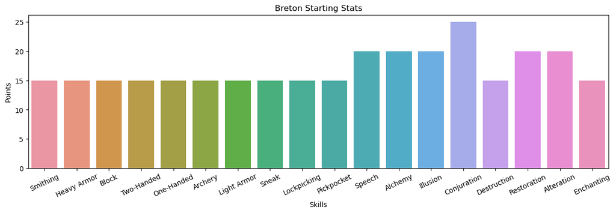

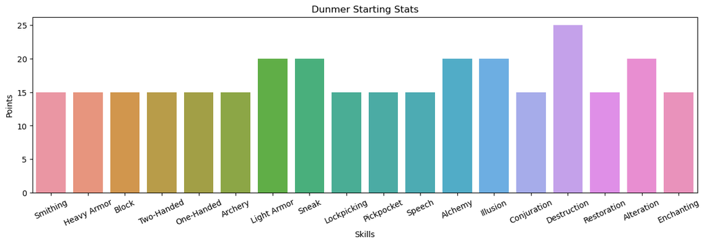

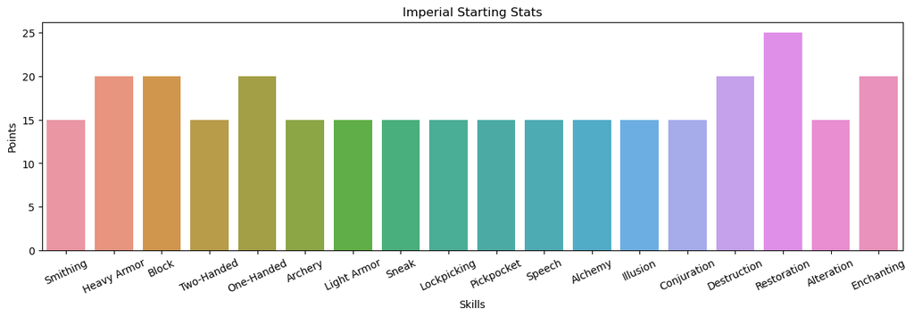

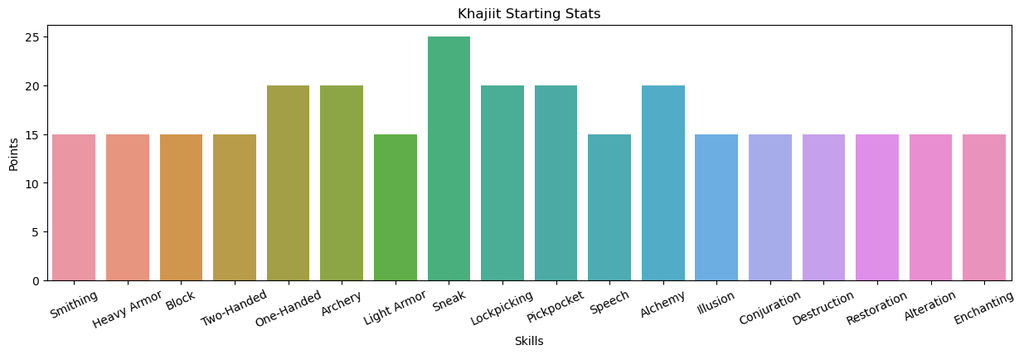

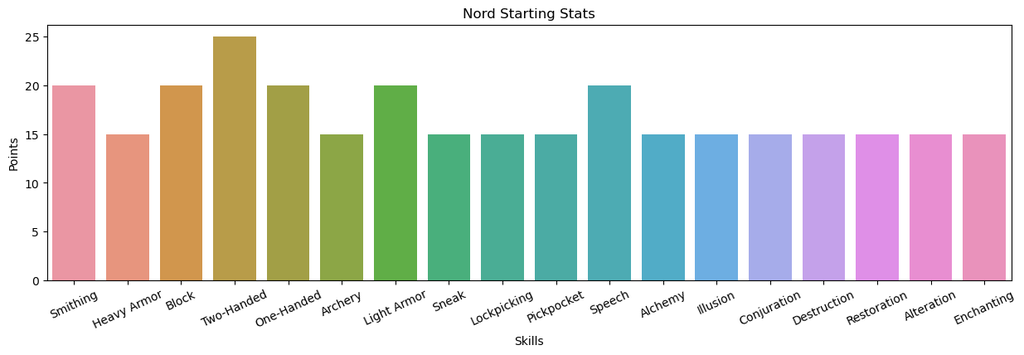

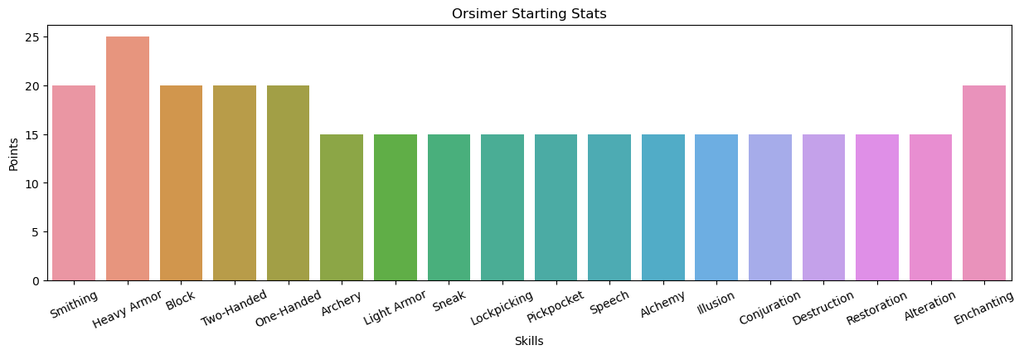

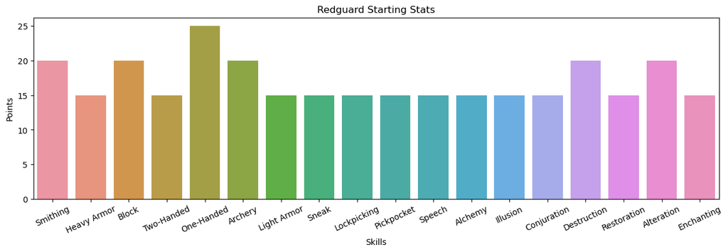

```python
races = ['Altmer','Argonian','Bosmer','Breton','Dunmer','Imperial','Khajiit','Nord','Orsimer','Redguard']

for race in races:

    plt.figure(figsize=(15, 4))
    sns.barplot(data=df,
            x='Skills',
            y=race)
    plt.title(f'{race} Starting Stats')
    plt.xlabel('Skills')
    # Rotate x-axis labels
    plt.xticks(rotation=25)
    plt.ylabel('Points')
    plt.show()
```

Even though there are already several resources to tell you the different stats of each race in Skyrim, I thought it would be fun to start my web scraping journey with something simple and a topic that I love! Personally, I enjoy the easy to look at charts. It allows me to quickly assess what race to start as if I want a specific build. For example, if I wanted a pure mage build, based on stats alone, I would need higher points in the magic skills. A quick glance through all of them shows me that Altmer is the way to go (my personal favorite).